# R programming II

Shamit Soneji

2023-12-01

# The fun starts now…

The purpose of this course is to extend your knowledge of R and start exploring the idea of classes, object-orientated programming, package creation and version control. This may all sound like jargon right now, but all will become clearer as we go on. By combining these skills the aim is that you will start developing your own tools and making them available for anyone to use.

This will be a fairly intense workshop, but it will boost your knowledge and confidence even further, and will hopefully teach you how to read other peoples’ code too which is very important.

# The story so far

You are here because you have a grasp of the R skills required to complete R Programming 1. See [here](https://sccbioinformatics.github.io/R_programming_1/) for the course material. In summary, that course covers:

- RStudio
  - Navigating the panes
  - Writing scripts
- Vectors
- Matrices
  - Subsetting
  - Manipulating
- Lists
  - Creating
  - Accessing
- Data Frames
  - Making ggplots from
- Reading and writing files
  - Reading in expression data
  - Writing out tables
- Flow control basics
  - `for`,`if`, `else` statements
- Functions
  - Creating
  - Using them
- `apply`
  - Using built-in functions like `sum` and `var`
  - Using `apply` with your own functions
- Standardising data
  - z-scoring data for clustering
- Clustering
  - Hierarchical clustering rows and columns
  - `pheatmap`
- Linear models
  - Writing the models
  - Extracting differentially expressed genes
- Kmeans
  - Programming from scratch
  - Starting to write algorithms
- The Final Project
  - Clustering using simulated annealing

If you aren’t comfortable with most of this list, then this course might not be for you.

## What will will cover

This course will take it up a notch, and we will demonstrate all the concepts mentioned earlier using single-cell data as our primary working material. Using this, we will learn how data is organised in R and how functions are written to analyse this data by using Seurat as an example. We will also learn how to make a small R package.

Importantly, we will learn how to use version control and Github to make your code available online to anyone. Your package will installable from anywhere with an internet connection. Because version control is so important, we will start with this.

# Git and Github

## What is git?

Git is program used for version control, and is an essential skill for anyone wanting to delve into software development of any kind. What we mean with version control is different versions of code, how multiple people can work on and collaborate to write code together, and how the work of multiple people can be merged together into one single project in a well-defined manner. Git (and its other version control counterparts) have a bit of a learning curve, and requires you to slightly adjust your regular workflow.

In this course you will learn how to use git and Github to manage your own code, you will learn the basic workflow of letting git document any changes you make to your code and make it available to anyone through Github. First of all: what is the difference between Git and Github?

[Git](https://git-scm.com/) is a free and open source program that you run on your computer, you let it know when you have made some changes to your code, it documents those changes along with a message of your choice. More on how to do this in a bit.

[Github](https://www.github.com/) is a website that hosts code and projects, in this course you will use github to host your code for you, and you use Git to upload your code there.

First, check if you already have git installed by typing `git` in a terminal. If you haven’t, install [git](https://git-scm.com/) through their website, or your favorite package manager. On a windows machine we recommend you install [git bash](https://gitforwindows.org/), it comes bundled with git.

Secondly, make an account on [Github](https://www.github.com/) and follow the [guide for how to generate and add SSH keys](https://docs.github.com/en/authentication/connecting-to-github-with-ssh). This lets you easily and securely authenticate yourself to Github and push your code changes through git.

## Setting up git

To start using git, navigate to a folder where you want to your project root to be and type `git init`.

Example:

```bash
$ mkdir my_first_repo
$ cd my_first_repo
$ git init
Initialized empty Git repository in /home/user/my_first_repo/.git/
```

#### Warning:

Depending on your installed version of git, you will likely be met with a warning message regarding the “default branch name” the first time you run `git init`, there is an ongoing change within the git community to rename the default branch from `master` to, usually, `main`. We recommend you run the `git config --global init.defaultBranch main` command, which will switch your default branch name to `main` for all future projects and suppress the warning. If you did run `git init` before reading this, you should also run `git branch -m main` to swap the name for this repository you just created.

## Some terminology

Git has a very exact terminology for things that we talk about in everyday software development. It greatly helps to learn these words and their meanings so we all know what we are talking about. Here we are going to go over some of the words that git uses.

- Working tree / Working directory  
  These are your local files, on your computer. You can think of your working tree as, what you see if you open up your project in a file browser.
- Repository  
  A repository is your working tree **and** the entire history of all changes ever made that were recorded with git. Typically you differentiate between your “local repository” and your “remote repository”. Each user that is working on a group project has their own copy of the repository, their own “local repository”. And collectively they have one “remote repository”, typically hosted on a service such as Github, that they all synchronize their changes through.
- Remote  
  A remote is a service/server where your code can be hosted, such as github. You have to specify a remote in Git, so it knows where to upload your code, and where to download other peoples’ changes from.
- Branch  
  You don’t have to worry about this one, move on.
- Staging area  
  After you have made some changes to one or more files in your working tree, you’ll need to tell git what changes you want recorded. You do this by adding the changed files to the staging area (this process is also called “to stage files”). Files aren’t modified or moved in your working tree when you stage them, they are just “moved to the stage” in git’s internal view of your working tree.
- Commit  
  You can think of a commit as one of two things, a set changes, or a point in time of your code development. Both of these are correct, and together they explain what a commit is.  
  A commit will always include all of the changes to all your files that you have added to the staging area, since your last commit. In the figure below, each commit is shown as a circle, the right-most green circle is the most current commit. All commits are given a “commit hash”, the seemingly random numbers and letters under each commit. These are actually 40 characters long, but are usually referred to using only the first 7 characters. Each commit also has a short message that summarizes what is in the commit. The arrows show which commit depends on which, not the direction of “time”.

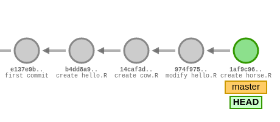

## The basic workflow

Now that you have made a local git repository and have learnt some of the commonly used words in git, lets create a file and document our first change.

```bash
$ echo "this file is amazing" > amazing.txt
$ git add amazing.txt
$ git commit -m "create an amazing file"
```

Let’s break down what we just did:

- `echo "this file is amazing" > amazing.txt`  
  Create a file that contains the text `this file is amazing`. So far so good.
- `git add amazing.txt`  
  All commands in git start with `git`, and then follows another command optionally followed by a file, and/or some options. `git add` is the command that moves a file to the staging area. Here we are saying to git: “The file `amazing.txt` has been changed (or created, in this case), I want that to be included in my next commit”.  
  If you have made changes to several files that you want to include in the same commit, you simply run `git add` for each file, or you can give the command a wildcard in the file name to include multiple files without running the command many times, for example, `git add *.R` would include every file that has the extension `.R`, in this folder. You can also use `git add path/to/some/folder` to include everything inside a folder (every file and sub-folder) in a commit.
- `git commit -m "create an amazing file"`  
  This command takes all files in the staging area, and makes a commit out of them. The `-m` option is used to include a short, descriptive message that summarizes the changes that this commit includes.

The first time you run `git commit` you will likely be met with another one-time error message. In order for git to create your commit you must sign it with your name and email. Go ahead and run the two lines that git hints at in the error message so git knows what name and email to sign your commits with.

```bash
$ git config --global user.email "you@example.com"
$ git config --global user.name "Your Name"
```

This will save your name and email to the global git config file (global, as in: it affects every user on your computer, not the whole planet), you can edit it at anytime with the command `git config --global -e`, or by running the above commands again. Any future repositories that you create on your computer will use the name and email in this file to sign your commits. Once you have done this, run `git commit` again to actually create the commit.

#### About `git add .` and `git add -A`

Git gives you the option to add every single modified file in your working tree to a commit by either specifying `.` (the folder you are currently in, which most of the time is the project root) as the file path, or with the `-A` option.

#### **You are highly discouraged from ever doing this.**

It is considered very bad practice to add every file, instead of specifying files manually. You might add sensitive files, files that are very large and clutter the remote repository, or include changes that are irrelevant to the commit or break the current state of the project for every other person working on it.

## The `git status` command

`git status` is an incredibly useful command when using and learning git. It will show you which state you are currently in, which files are staged and not staged, how many commits ahead or behind you are. Let’s see what the state of our repository is after we have made our previous commit.

```bash
$ git status
On branch main
nothing to commit, working tree clean
```

The command first tells us that we are on the branch `main`, as we said earlier, you don’t have to worry about what this means. Secondly, it tells us that there is nothing to commit and that the working tree is clean. Makes sense, we just made a commit with all the changes we made (creating the `amazing.txt` file) and haven’t done any changes since.

Let’s make a change to our `amazing.txt` file and see what `git status` tells us.

```bash
$ echo "more amazing text" >> amazing.txt
$ git status
On branch main
Changes not staged for commit:
  (use "git add <file>..." to update what will be committed)
  (use "git restore <file>..." to discard changes in working directory)
    modified:   amazing.txt

no changes added to commit (use "git add" and/or "git commit -a")
```

Now, git recognizes that `amazing.txt` has been changed, but tells us that we haven’t added those changes to the stage, and gives us some familiar hints on how to use `git add`.

It also hints us about one of the usages of `git restore`, a command we haven’t mentioned yet. **Note that running** `git restore amazing.txt` **would delete our changes that we have made to this file. This can not be undone.**

It also tells us that the next commit is, so far, empty.

Let’s run `git add` and see what `git status` returns.

```bash
$ git add amazing.txt
$ git status
On branch main
Changes to be committed:
  (use "git restore --staged <file>..." to unstage)
    modified:   amazing.txt
```

Now git shows us that the changes have been staged, and are ready to be committed. Should you here realize that you don’t want those changes in this commit, git also gives us another hint on how `git restore --staged` works. Here, it’s basically the opposite of `git add`, instead of adding a file to the stage, it removes it from the stage. This time, the contents of the file would be untouched by git, it’s just git’s view of your working tree that is changed. Be very careful when unstaging files so you don’t accidentally lose any work.

Instead of using `git restore` and/or `git restore --staged`, I recommend you use `git reset` to unstage files. `git reset` won’t change the contents of your files unless you pass the `git reset --hard` option and using `git reset` on a file that is not staged, simply does nothing. This has (in my experience) been less likely to result in lost work.

Let’s make a commit to return to the state we were in before this section.

```bash
$ git commit -m "add more amazingness"
```

Familiarizing yourself with `git status` is immensely useful and we recommend that you run `git status` in between every git command you type during this course.

## Git with a remote

So far we have only worked with git locally, our files have never left our working tree.

The two main commands to interact with a remote (such as a repository hosted on Github), are `git push` and `git pull`.

Try typing `git push` and see what happens.

```bash
$ git push
fatal: No configured push destination.
Either specify the URL from the command-line or configure a remote repository using

    git remote add <name> <url>

and then push using the remote name

    git push <name>
```

Git gives us an error message because we haven’t specified where our remote is, yet.

We will go back to this in a moment, but first, let’s create our remote. Go to Github and create a new repository [here](https://github.com/new). You will use this repository for the rest of the course. You can give it any name you want, but we recommend something like `R-Programming-2`. You can leave it to be public, in which case it will be visible to anyone on the internet, or make it private so only you, and anyone you invite to the repository can view it.

After this, you will be redirected to a page with a lot of text and git commands. Hopefully at this point, some of them are familiar to you!

We have already made a repository locally, but let’s start with a fresh one for this part. Make a new folder named the same thing as your repository and follow the code in the first box. You don’t *have* to name the folder the same thing as the remote repository, it’s just good practice.

```bash
$ mkdir R-Programming-2
$ cd R-Programming-2
$ echo "# R-Programming-2" >> README.md
$ git init
$ git add README.md
$ git commit -m "first commit"
$ git branch -M main
$ git remote add origin git@github.com:<YOURNAME>/R-Programming-2.git
$ git push -u origin main
```

The last two commands are the ones we haven’t covered yet. `git remote` adds a new remote (the repository on github) with the name `origin` (the default name for this kind of usage of git) and then there is a long URL, swap out `<YOURNAME>` with your github username.

Finally, we use `git push` to upload our changes (the creation of the `README.md` file) to the remote we just named `origin`, on the branch `main`. There’s a lot of new words in this section, but you don’t have to worry about what they mean exactly for now. Just know that the first time you run `git push` in a new repository, you have to specify the remote with `git remote` and run `git push` with the `-u origin main` option to save it as something called the “upstream”. For all future commits that you want to push, it’s enough to run only `git push`.

Whenever there are changes made by anyone else working in the same repository, you can download those changes with `git pull`. In this course however, you will be working alone in your repository.

## Why use Github as a PhD/postdoc?

For a software developers, their Github profile is what potential employers will look at to see a) what kinds of projects they have done, and b) check the standard/level of their work. For a researcher like yourself, just having a Github profile will raise your standing above other candidates that do not do this. Your code *doesn’t* have to be amazing, but having the confidence to put it online is an impressive quality that *most* future employers will appreciate.

## Further reading

There is *a lot* more that git can do that we haven’t covered in this version control crash course. If you have time, you can familiarize yourself with some of the more advanced concepts of git here.

Click on a word to expand.

**The `.gitignore` file**

If you don’t want a file to ever be included in a commit, and you don’t want to see it in the `git status` command when there are changes in the file, you can add the file to the `.gitignore` file. This file should be in the root of your repository. Any file mentioned in the `.gitignore` will be ignored by commands such as `git status` and `git add`. This is useful for files containing sensitive information, files that are generated when building or running your code, user-specific configuration files, or files that are just for testing.

In the `.gitignore`, each file you want ignored should be on a separate line, comments can be written by starting a line with a `#`. Just like `git add`, the `.gitignore` file allows wildcards or directories as input, and will ignore any files matching the wildcard, or any files inside the directory that is ignored.

**`git clone`**

Downloading a repository is often called “cloning” the repository, because the command to do so is `git clone <url>`. Anyone can clone any public repository on Github (or similar websites), but you need special permissions to be able to `push` any commits back up to the repository.

**`head` and `git checkout`**

Git keeps track of where your working tree is in relation to the repository by using something calls `heads`. A `head` is basically a pointer to a specific commit. Confusingly, the `head` that your working tree is at at any time, is named `HEAD`, in all caps. You can move your working tree’s `head` (the one named `HEAD`) using `git checkout <commit hash>`. This will make git backtrack through its history and change the files in your working tree to exactly what they were when the commit you entered was made. To go back to the most current state of the repository, use `git checkout <branch name>`.’

**`git checkout <file>`**

This command will overwrite `<file>` with the version that was in the last commit. Useful if you accidentally deleted a file and need it back, or are unhappy with some changes and want the old version again. Note that this command **cannot be undone**.

**Branches**

Branches are a key concept in working with multiple people in the same project. A branch is a lot like a brand new copy of the repository, that you can commit changes to without it affecting the main branch. Finally, you would merge the newer branch back into the main branch. You can swap to a new branch using `git branch <branch name>` and then `git checkout <branch name>`. Any commits you make after this will not be visible to anyone on the main branch, or any other branch. There is no limit to how many branches might exist at any point, and branches don’t have to all originate from the main branch, they could be a branch from a branch (and so on).

Once all work is done on a branch, you merge it back by switching to the branch you want to merge *into*, say we want to merge the branch `new_branch` into the branch `main`, you would run `git checkout main` and `git merge new_branch`.

The most common use case for branches is for developers to create their own little safety bubble where the commits of others working on the same project can not break their code they are working on, and they can not risk breaking anyone else’s code. Typically in larger projects, anytime a developer starts working on a new feature, they will create a branch for it, implement said feature on their new branch, and then merge it back into the main branch.

Each branch has its own `head`, with the name that you named the branch. You can interact with these `heads` using `git checkout` and `git reset`, but be aware that this can permanently delete commits.

**Forks and pull requests**

A common feature that is used in the world of git is forking a repository. Forking a repository is basically downloading a copy of someone else’s repository, and then uploading that copy under your account, as a new repository marked as a fork. This is a common way for developers to create features or fix bugs in open source software, when they don’t have the permissions to push commits directly to the original repository.

Once a feature or bug fix has been done in a forked repository, the developer will make what is called a “pull request” in the original repository. This is a request for the developers in the original repository to pull the changes that were made in the fork. This is typically also done through “issues”, which are concerns or feature requests that users or developers can make through a forum-like part of websites like Github. Pull requests can be directly linked, viewed, discussed, approved, and merged through the issue tracker.

**`git reset`**

**Always make at least one backup before running `git reset`.**

`git reset` is a very powerful, and potentially, very destructive command. It has no confirmation and can delete your files and commits when used. You can use `git reset <file>` to unstage a file, this is similar to `git restore --staged <file>` and does not change the contents of the file.

Using `git reset <commit hash>` will move your `HEAD` **and your branch’s** `head` to that commit. **This will delete any commits made after the commit you reset to from git’s history. This can not be undone or recovered from if you have not pushed those commits to a remote**. Using `git push` after using `git reset` this way will **overwrite the remote repository, deleting the commits from the remote**. This is useful if you need some commits deleted from the history because you pushed sensitive files that should not be public, but incredibly damaging when used the wrong way.

**`git show` and `git log`**

Both these commands show the recent history in your local repository. `git show` will show what was in the most recent commit. `git show --online` is convenient if you need the last commit hash for example. `git log` will show the last 5 commits in a shorter format. If you want this formatted in a nicer way, we recommend you run

```bash
$ git config --global alias.hist "log --pretty=format:'%C(yellow)[%ad]%C(reset) %C(green)[%h]%C(reset) | %C(red)%s %C(bold red){{%an}}%C(reset) %C(blue)%d%C(reset)' --graph --date=short"
```

This configures a new git command `git hist` which summarizes each commit with pretty colours, and displays all branches with some nice lines.

**`git stash`**

Whenever you merge changes from someone else, you will likely run into some merge conflicts. Whenever two people have commits that contain changes to the same parts of the same file, git won’t always know what to do. There are two versions of this file that git considers equally “new”. Before you merge a branch, it is useful to stage your files, and run `git stash`, this will change the files in your working tree. Git will rollback the tracked files to the version they were at the last commit, you can then `git pull` someone’s changes and then use `git stash pop` to resolve the conflicting files locally, and commit the updated changes.

**Credential managers**

Depending on your system and setup, you might have access to some credential manager that can save your password for each session. You can type `git config --global credential.helper manager` or `git config --global credential.helper cache` to use these.

**Using git from a GUI.**

GUI stands for graphical user interface, and is sometimes used to refer to “any program that isn’t run through only a terminal”. The author of this part of the course is a grumpy and stubborn old fart that refuses to use git from anything that isn’t a terminal. As you are still learning, there is still hope for you. There are plenty of free git GUI clients available, like [GitKraken](https://www.gitkraken.com/), [GitHub Desktop](https://desktop.github.com/) or [SourceTree](https://www.sourcetreeapp.com/) to name a few. If you are feeling like the terminal isn’t for you, we encourage you to experiment with these and find one you like.

Note that using a GUI client doesn’t mean you can not use the terminal also, you can always open your local repository and execute commands from a terminal and then return to the GUI and keep working from there.

**Useful links**

[Official git documentation](https://git-scm.com/doc)  
[Git visualiser](https://git-school.github.io/visualizing-git/)  
[Codecademy git tutorial](https://www.codecademy.com/learn/learn-git)  
[A more technical tutorial](https://www.cduan.com/technical/git/)

# R II

The aim of this section is to serve as a reminder how data is stored in R, particularly matrices, data frames and lists.

## Getting some data

We will use the standard Peripheral Blood Mononuclear Cells (PBMC) data made and supplied by 10X. It is a small dataset and will serve as a good example. What we are going to do together is create our own stripped-down version of Seurat. This will teach you:

1. How single-cell data is pre-proccessed.
2. How single-cell and its metadata is stored in R.
3. Writing functions to analyse this data.
4. Packaging these functions into a well documented package for use by anyone, anywhere.

Go to the official tutorial on the Seurat website [here](https://satijalab.org/seurat/articles/pbmc3k_tutorial). We will use it to follow along as we write our package to try and do roughly the same thing.

Unlike the R programming I course, you can use ChatGPT if you get stuck, we may as well embrace new tools when they become available.

There is a file called “PBMC_data.rds”. The file suffix “.rds” means the file is a “R Data Serialization” file.

*Exercise:* Look up how to load this file, and load it into a variable called “pbmc.data”.

```r
pbmc.data <- readRDS("PBMC_data.rds")
```

After loading the data we can get its dimensions:

```r
dim(pbmc.data)
```

```
## [1] 32738  2700
```

*Exercise:* This is important, find out what class of object it is.

```r
class(pbmc.data)
```

As we (hopefully) know it is faster to work on a matrix than a data frame. Convert it to a matrix and overwrite the same variable name “pbmc.data”.

```r
pbmc.data <- as.matrix(pbmc.data)
```

## QC

This is where we can start to look at doing some basic QC and filtering. We’ll use the Seurat PBMC tutorial and copy their process as much as possible.

*Exercise:* Go to the tutorial page and look the first violin plot. Using your matrix of count data, reproduce the plot you see there using ggplot2. You’ll need to calculate “nFeature_RNA”, “nCount_RNA”, and “percent.mt” first! **In a departure from R Programming I, you can use ChatGPT for help**.

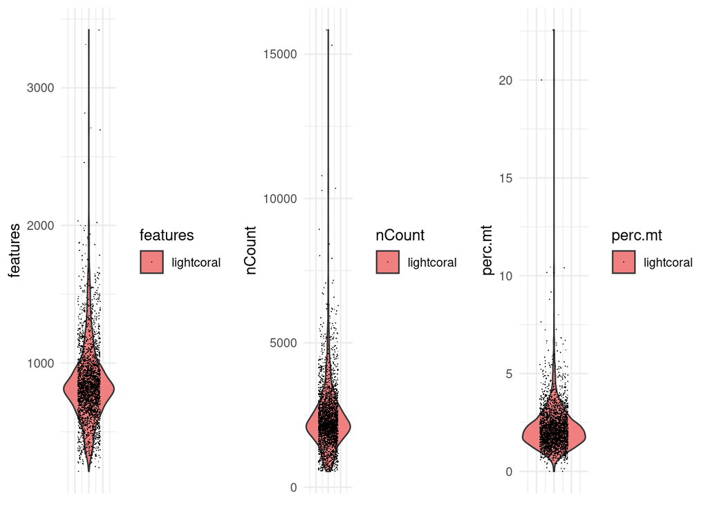

```r
library(ggplot2)
library(gridExtra)

features <- apply(pbmc.data >0, 2, sum)
nCount <- apply(pbmc.data,2,sum)
perc.mt <- 100*apply(pbmc.data[grep("^MT-",rownames(pbmc.data)),],2,sum)/apply(pbmc.data,2,sum)

min.cls <- apply(pbmc.data >0, 1, sum)

qc.df <- data.frame(features=features,nCount=nCount,perc.mt=perc.mt)
fill_color <- "lightcoral"

plots <- lapply(names(qc.df), function(variable) {
  ggplot(qc.df, aes(x = 1, y = qc.df[[variable]], fill = fill_color)) +
    geom_violin() +
    labs(x = NULL, y = variable) +
    scale_fill_manual(values = fill_color, name = variable) +  # Set the fill color
    theme_minimal() +
    theme(axis.text.x = element_blank(),
          axis.ticks.x = element_blank()) +
    geom_jitter(shape=".", position=position_jitter(0.2))
})

grid.arrange(grobs = plots, ncol = length(plots))
```

When you have made something like the above, make the scatter plots which are next in the Seurat tutorial using the numbers you have just calculated.

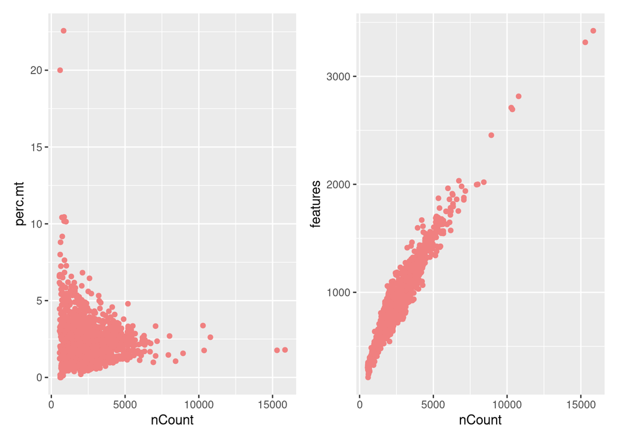

```r
library(patchwork)
p1 <- ggplot(qc.df, aes(x=nCount, y=perc.mt)) + geom_point(color = fill_color)
p2 <- ggplot(qc.df, aes(x=nCount, y=features)) + geom_point(color = fill_color)
p1+p2
```

We have the plots we need to filter the data. Using the same filtering criteria setout in the tutorial, filter the expression data and the metadata you calculated. Check the number of cells and genes you have match what they have in the tutorial.

```r
library(dplyr)
meta <- qc.df %>% filter(features  <= 2500) %>% filter(features  >= 200) %>% filter(perc.mt <= 5)

count.filt <- pbmc.data[names(which(min.cls>2)),rownames(meta)]
dim(count.filt)
```

```
## [1] 13714  2638
```

This looks like a good point to take a breather from R and save our work to our Github repository that we made earlier.

Run `git status`, stage your file(s), make your changes into a commit and push it to our remote.

```bash
$ git status
$ git add path/to/my_script.R
$ git commit -m "create data reader and filtering"
$ git push
```

# Storing multiple data objects in R

## Lists

We need to put the meta data and the count data in the same R object to keep everything together. From the last tutorial, you will remember we did this using lists:

```r
pbmc <- list(meta=meta, counts=count.filt)
names(pbmc)
```

```
## [1] "meta"   "counts"
```

A recap on accessing data objects:

```r
pbmc$meta[1:10,] # access the first 10 rows of the metadata
```

```
##                  features nCount   perc.mt
## AAACATACAACCAC.1      781   2421 3.0152829
## AAACATTGAGCTAC.1     1352   4903 3.7935958
## AAACATTGATCAGC.1     1131   3149 0.8891712
## AAACCGTGCTTCCG.1      960   2639 1.7430845
## AAACCGTGTATGCG.1      522    981 1.2232416
## AAACGCACTGGTAC.1      782   2164 1.6635860
## AAACGCTGACCAGT.1      783   2176 3.8143382
## AAACGCTGGTTCTT.1      790   2260 3.0973451
## AAACGCTGTAGCCA.1      533   1276 1.1755486
## AAACGCTGTTTCTG.1      550   1103 2.9011786
```

```r
pbmc[[1]][1:10,] # same as above
```

```
##                  features nCount   perc.mt
## AAACATACAACCAC.1      781   2421 3.0152829
## AAACATTGAGCTAC.1     1352   4903 3.7935958
## AAACATTGATCAGC.1     1131   3149 0.8891712
## AAACCGTGCTTCCG.1      960   2639 1.7430845
## AAACCGTGTATGCG.1      522    981 1.2232416
## AAACGCACTGGTAC.1      782   2164 1.6635860
## AAACGCTGACCAGT.1      783   2176 3.8143382
## AAACGCTGGTTCTT.1      790   2260 3.0973451
## AAACGCTGTAGCCA.1      533   1276 1.1755486
## AAACGCTGTTTCTG.1      550   1103 2.9011786
```

```r
pbmc$counts[1:5,1:10] # first 5 rows and 10 columns of the count data.
```

```
##               AAACATACAACCAC.1 AAACATTGAGCTAC.1 AAACATTGATCAGC.1
## AL627309.1                   0                0                0
## AP006222.2                   0                0                0
## RP11-206L10.2                0                0                0
## RP11-206L10.9                0                0                0
## LINC00115                    0                0                0
##               AAACCGTGCTTCCG.1 AAACCGTGTATGCG.1 AAACGCACTGGTAC.1
## AL627309.1                   0                0                0
## AP006222.2                   0                0                0
## RP11-206L10.2                0                0                0
## RP11-206L10.9                0                0                0
## LINC00115                    0                0                0
##               AAACGCTGACCAGT.1 AAACGCTGGTTCTT.1 AAACGCTGTAGCCA.1
## AL627309.1                   0                0                0
## AP006222.2                   0                0                0
## RP11-206L10.2                0                0                0
## RP11-206L10.9                0                0                0
## LINC00115                    0                0                0
##               AAACGCTGTTTCTG.1
## AL627309.1                   0
## AP006222.2                   0
## RP11-206L10.2                0
## RP11-206L10.9                0
## LINC00115                    0
```

**They work, but Why should we not use lists?**

# S4 classes

S4 classes can be thought of as a list, but with with options to add security. Bioconductor packages are based in S4 classes, as is Seurat which is why we are going to make it our focus here.

Lets setup an S4 class so you can see how it works:

```r
setClass("mysco",slots= c(meta="data.frame",counts="matrix"))
```

In this line we define what your mysco class/container will accept. Here, only data frames and matrices will be accepted. Lets make an S4 object containing some data:

```r
pbmc <- new("mysco",meta=meta,counts=count.filt)
```

You can see that when you call `pbmc` in the console it will splurge all the data onto the screen. Now is a good time for us to define a function that summarises the objects contents:

```r
setMethod('show', signature = c ('mysco'),
        definition = function (object) {
            cat (paste("An object of class", class(object)),"\n" )
            cat (paste( 'with',nrow(object@counts),'genes and', ncol(object@counts),' cells.'),"\n")
        }
)
```

Lets try it:

```r
pbmc
```

```
## An object of class mysco
## with 13714 genes and 2638  cells.
```

You can see this is a really nice way of summarising the contents of an object. It’s good practise to update this function to summarise any extra elements you add, it will help you track everything going on as you progress with the anlaysis.

## How do I access an S4 class?

To access *slots* of an S4 class you need to use the `@` symbol. For example:

```r
pbmc@meta[1:5,] #access the first 5 rows of the metadata
```

```
##                  features nCount   perc.mt
## AAACATACAACCAC.1      781   2421 3.0152829
## AAACATTGAGCTAC.1     1352   4903 3.7935958
## AAACATTGATCAGC.1     1131   3149 0.8891712
## AAACCGTGCTTCCG.1      960   2639 1.7430845
## AAACCGTGTATGCG.1      522    981 1.2232416
```

```r
pbmc[[1]][1:5,] #does this work?
```

## Why S4 is useful

In the definition of the class we’ll see that a matrix is required. Lets see what happens when you try and give it something else:

```r
pbmc <- new("mysco",meta=meta,counts=data.frame(count.filt))
```

```r
pbmc.v2 <- new("mysco",meta=meta,counts=count.filt[,-(1:5)]) # remove the first 5 columns (cells) of the data.
```

Why is this a terrible thing to do?

```r
setValidity("mysco", function(object) {
  if (ncol(object@counts) != nrow(object@meta)) {
    "@counts and @meta must be the same length"
  } else {
    TRUE
  }
})
```

We can try to make a new mysco object removing a few cells:

```r
pbmc.v3 <- new("mysco",meta=meta,counts=count.filt[,-(1:5)]) # remove the first 5 columns (cells) of the data.
```

What happened? You can see that S4 classes are a very safe way of storing data in R because their contents have to be controlled for class and dimensions. Lots of functions fail because what is supplied is not correct. By enforcing standards in a class it should minimise these issues in the future.

*Exercise:* Extend this validator to check the cell IDs match in the data and metadata.

This is also a good time to make a commit and push our work so far to Github.

## Wrapper and accessor functions

Have a look at the Seurat tutorial. You will see a function called `CreateSeuratObject`. This function takes a matrix and then automatically calculates the `features`, `nCounts` and puts it into metadata.

*Exercise:* Create a function called `CreateMySCO` which takes a data matrix (`pbmc.data`) and creates an mysco class containing the raw unfiltered data and the `features`/`nCounts` in the meta slot. Call the resulting object `pbmc`, hence over-writing the current one.

```r
CreateMySCO <- function(mat){

  features <- apply(mat >0, 2, sum)
  nCount <- apply(mat,2,sum)

  df <- data.frame(features=features,nCount=nCount)

  msc <- new("mysco",meta=df,counts=mat)
  msc
}
```

```r
pbmc <- CreateMySCO(pbmc.data)
pbmc
```

```
## An object of class mysco
## with 32738 genes and 2700  cells.
```

*Exercise:* You will see the class reports back the original dimensions of the data. Now that we have this write a function that will calculate the mitochondrial percentage and add this to the metadata (use the code you already have above). Look at the Seurat tutorial for inspiration. Call the function `CalcMitoPct`.

```r
CalcMitoPct <- function(mysco,prefix){

  mtpc <- 100*apply(mysco@counts[grep(prefix,rownames(mysco@counts)),],2,sum)/apply(mysco@counts,2,sum)
  mysco@meta$perc.mt <- mtpc
  mysco
}
```

```r
pbmc <- CalcMitoPct(pbmc,"^MT-")
```

*Exercise:* Using the ggpot code you already have, put it into a function that takes your mysco S4 object and makes the qc violin and scatter plots. Call this function `MakeQCPlots`

```r
MakeQCPlots <- function(mysco){

  qc.df <- mysco@meta

  plots <- lapply(names(qc.df), function(variable) {
    ggplot(qc.df, aes(x = 1, y = qc.df[[variable]], fill = fill_color)) +
      geom_violin() +
      labs(x = NULL, y = variable) +
      scale_fill_manual(values = fill_color, name = variable) +  # Set the fill color
      theme_minimal() +
      theme(axis.text.x = element_blank(),
            axis.ticks.x = element_blank()) +
      geom_jitter(shape=".", position=position_jitter(0.2))
  })
  #grid.arrange(grobs = plots, ncol = length(plots))

  plots[[4]] <- ggplot(qc.df, aes(x=nCount, y=perc.mt)) + geom_point(color = fill_color)
  plots[[5]] <- ggplot(qc.df, aes(x=nCount, y=features)) + geom_point(color = fill_color)

  grid.arrange(grobs = plots, ncol = 3)

}
```

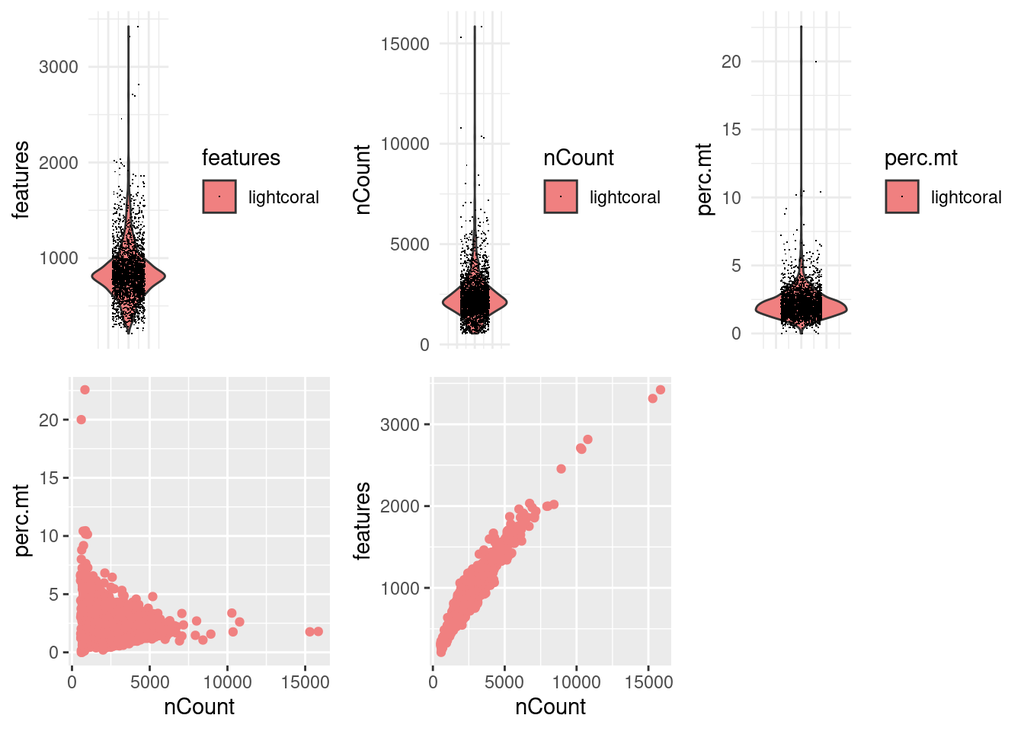

```r
MakeQCPlots(pbmc)
```

We need a function to filter the data. Write one that does what we did earlier, plus, has an argument that lets the user specify which genes should be removed if they aren’t expressed in $x$ cells or more (`min.cells = 3` in the Seurat tutorial).

```r
FilterData <- function(mysco,sub,min.cells){

  min.cls <- apply(mysco@counts >0, 1, sum)

  d.filt <- subset(mysco@meta, eval(parse(text=sub)))
  mysco@meta <- d.filt
  mysco@counts <- mysco@counts[which(min.cls>=min.cells),rownames(d.filt)]
  mysco
}
```

Lets use it:

```r
pbmc <- FilterData(pbmc,sub="features > 200 & features < 2500 & perc.mt < 5",min.cells=3)
pbmc
```

```
## An object of class mysco
## with 13714 genes and 2638  cells.
```

Once your new functions are all working, make another commit and push your work to Github.

# Packages

We have have a few functions in our back pocket now, but before we carry on making more functions it makes sense to start thinking about making an R package to contain an document all of our functions. Our package will be pushed up to Github where it will be available to use by you, and anyone else in the world. This is how Seurat was made available in the early days before it was officially submitted to CRAN.

Making an R package was something of a pain in the early days, but now things like Rstudio make it much easier by providing the skeleton of a package that you can use as a template.

## Start a new package

1. Open a new Rstudio window/session and go to “New Project” > “New Directory” > “R Package”
2. Type in the name you want to give the package (I’ll call mine “SCAP”, Single-cell Anaysis Package), and tell Rstudio where you want this project folder to be created.

Rstudio will make the folder and change you session directory to it.

3. Go to Github and make a new repository. Give it the same name as your package name.
4. When you create the repo you will see some lines of code to perform your first push. In my case:

```bash
$ echo "# SCAP" >> README.md
$ git init
$ git add DESCRIPTION  man  NAMESPACE  R  README.md  SCAP.Rproj .Rbuildignore
$ git commit -m "first commit"
$ git branch -M main
$ git remote add origin git@github.com:shambam/SCAP.git
$ git push -u origin main
```

5. Open a terminal and navigate to your project folder and execute these lines. **Don’t forget to swap “shambam” with your own Github ID**.
6. Once you have done this you are ready to push you package up to Github as you create it.

If you run `git status` in your newly created directory you will see the `.Rproj.user` directory, marked as “untracked”. You shouldn’t push this directory as it only contains user specific settings, and we don’t want to override anyone else’s settings if they choose to clone our project. This is a prime example of why you should never use `git add .`. If we don’t want to accidentally include this file in any future commit, we can add it to a file called `.gitignore`. Go ahead and create this file using

```bash
$ echo ".Rproj.user" > .gitignore
```

You can add any future files or directories you don’t want to include in commits by adding them to this file, one item per line. Go ahead and add the `.gitignore` file as well to a new commit and run `git status` to make sure `.Rproj.user` doesn’t pop up there anymore. As a small bonus exercise; what happens if you run `git add .Rproj.user` when it is in our `.gitignore`?

## The anatomy of a package

You will see a few files and folders in your package directory. The important ones are:

1. **DESCRIPTION** This file is where you add details about your package and what the package does. Take a moment to fill out some of the details. When you save the file, it will appear in the “Git” window (top right pane). If you want to push this file to Github you can check the box next to the file and hit “commit”. A window will open showing when in the file has changed, and in the top right you can write a commit message. Write a commit message and then commit the file. You will go back to the main window where you can push the file using the upward pointing green arrow.

**You don’t have to do this every time you change a file.**

2. **R** This folder is where your code goes. In the files pane (bottom right) click into the folder and open hello.R. You can see it’s a very simple function that prints ““Hello, world!” when called. Let install this simple package. In the the build tab click the install button.

The package will install and your `SCAP` library will automatically be called. In the terminal do:

```r
hello()
```

Do this:

```r
?hello
```

```
## No documentation for 'hello' in specified packages and libraries:
## you could try '??hello'
```

```
#' A header line for your package
#' @name hello
#' @description A simple function that prints a welcome
#` @return Prints "Hello, world!"`
#' @examples
#' hello()
#' @export

hello <- function() {
  print("Hello, world!")
}
```

Before we can build the documentation we need to install the package that will do it. **Note**, you may need to install the `stringi` package first, but see if it works without first!

```r
install.packages("roxygen2")
```

Go to “More” > “Configure Build Tools…” and check the box that says “Generate documentation with Roxygen”. At the bottom check “Install and restart”. Now when you install the package Rstudio will automatically generate the hello.Rd file from the lines of documentation you have written above.

This is great because all the documentation is kept in the same file as the code which means both can be written together easily.

## Adding dependencies.

Dependencies are other packages that your own package needs to function. For example, to make the QC plots you’ll need the `ggplot2` library. To add this, open the DESCRIPTION file.

You add a package by making an imports section:

```
Package: SCAP
Type: Package
Title: Single-cell Analysis Package
Version: 0.1.0
Author: Shamit Soneji
Maintainer: Shamit Soneji <shamit.soneji@med.lu.se>
Description: A dummy package
License: None
Encoding: UTF-8
LazyData: true
RoxygenNote: 7.2.3
Imports:
  ggplot2,
  dplyr
```

When these are used in your code the libraries are called. Another cool safeguard is to do the following:

```
Package: SCAP
Type: Package
Title: Single-cell Analysis Package
Version: 0.1.0
Author: Shamit Soneji
Maintainer: Shamit Soneji <shamit.soneji@med.lu.se>
Description: A dummy package
License: None
Encoding: UTF-8
LazyData: true
RoxygenNote: 7.2.3
Depends:
    R (>= 4.0.0)
Imports:
  ggplot2,
  dplyr
```

By adding this you ensure that whoever is installing it has at least version 4 or R or higher. If they don’t then it won’t install. Be nice, if your pacakge is simple then omit this so as many people as possible can use it.

Now that we have the basics of what we need, we can start to “transplant” some of our code into a package.